# Capstone Project

1/24/2021

## Capstone Usage:

- We will try to Predict Next Word user might want to type
- Text: This is the prefix of text use to find the next word
- NGrams: Number of last words in the text above to be tokenize.
- Submit: Click on Submit Button
- On right top Pane shows the Options of most used phrases based on Ngrams chosen
- On right lower Pane shows the predicted next word

## How it Works:

- For example lets take our sentence as “an issue we raised in our”
- Ngrams are assumed to be 3
- We would define a function to read lines of smaller versions of Blogs, News and Twitter text files each containing 2000 lines -After it finds the last Ngram words, it will also collect the next word and put into a vector

```r
findOurSent<- function(file, sentence) {
  con <- file(file, "r")
  sentences = c()
  counter = 0
  while ( TRUE ) {

    line = readLines(con, n = 1, skipNul=T,warn=FALSE)
    if ( length(line) == 0 ) {
      break
    }else{

      if(grepl( sentence, line, fixed = TRUE)) {
        counter = counter+1
        loc<-str_locate(line, sentence)
        lastWord2<-str_locate(substr(line,loc[1,2]+1,nchar(line))," ")#find next space
        sentences[counter] = substr(line,loc[1,1],(loc[1,2]+lastWord2[1,1]))
        if(counter>200) {
          break
        }
      }
    }
  }
  close(con)
  sentences
}
```

## Processing the Results

- We will run this function for each of the files

```r
sentence <- 'in our '

newsfinds=findOurSent("~/R/Coursera/Capstone Project/final/en_US_small/en_US.news.txt",
                      sentence)
blogsfinds<-findOurSent("~/R/Coursera/Capstone Project/final/en_US_small/en_US.blogs.txt",
                        sentence)
twitterfinds<-findOurSent("~/R/Coursera/Capstone Project/final/en_US_small/en_US.twitter.txt",
                          sentence)
```

- Combine them into a vector, clean lines with NA

```r
all_data = c(newsfinds,blogsfinds,twitterfinds)
all_data[which(is.na(all_data))] <- "NULLVALUEENTERED"
```

- Define Ngram tokenizer, use it into Document Matrix. We assume the N-grams chosen are 3

```r
twitter.Corpus <- VCorpus(VectorSource(all_data))
NthgramTokenizer <- function(x) NGramTokenizer(x, Weka_control(min=3, max=3))
dtm <- DocumentTermMatrix(twitter.Corpus, control = list(tokenize=NthgramTokenizer))
```

## Part 2 Processing the Results

- We will create data frame that will sort this matrix based on frequency in descending order

```r
frequencyPerWord <- sort(colSums(as.matrix(dtm)), decreasing=TRUE)
frequencyPerWord <- data.frame(
  word = names(frequencyPerWord),
  frequency = frequencyPerWord
)
```

- We will consider first 5 tokens which are most frequently used

## Plot the top 5 results

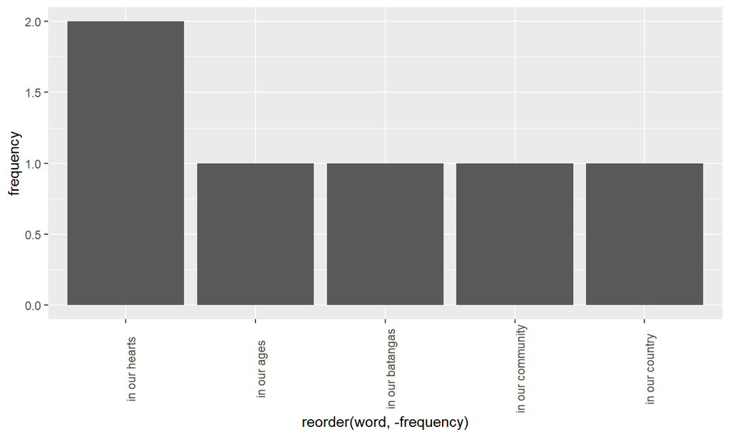

## Predict the next word

We can the take the phrase and separate last word

```r
List <- strsplit(frequencyPerWord[1,]$word, " ")
lastWord<-List[[1]][(length(List[[1]]))]
lastWord
```

```
## [1] "hearts"
```